# The Titanic, Class Questionnaire (and Practicing R Best Practices)

We can rotate the axis labels by tweaking the `las=` argument.

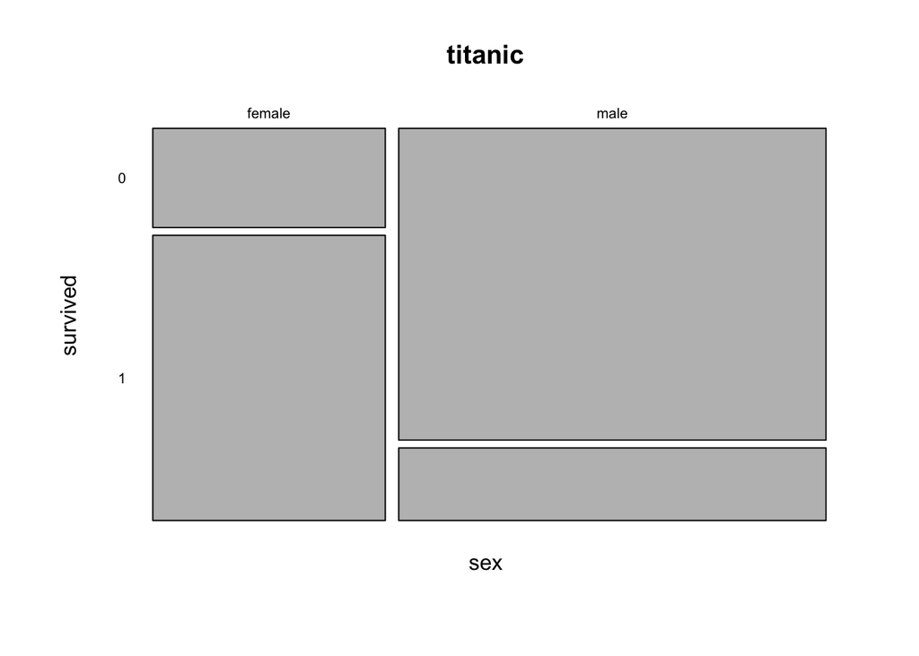

```r
mosaicplot(sex ~ survived, data=titanic, las=1)
```

We can make the axis text bigger by changing `cex=`.

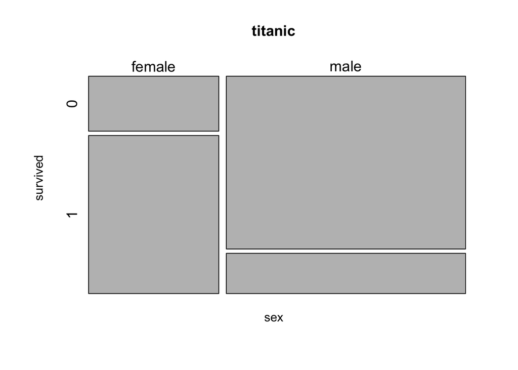

```r
mosaicplot(sex ~ survived, data=titanic, cex=1.2)
```

Another way to do a mosaic plot is to use the `plot()` function again. Unfortunately, the `las=` axis label rotation functionality seems incompatible with this approach.

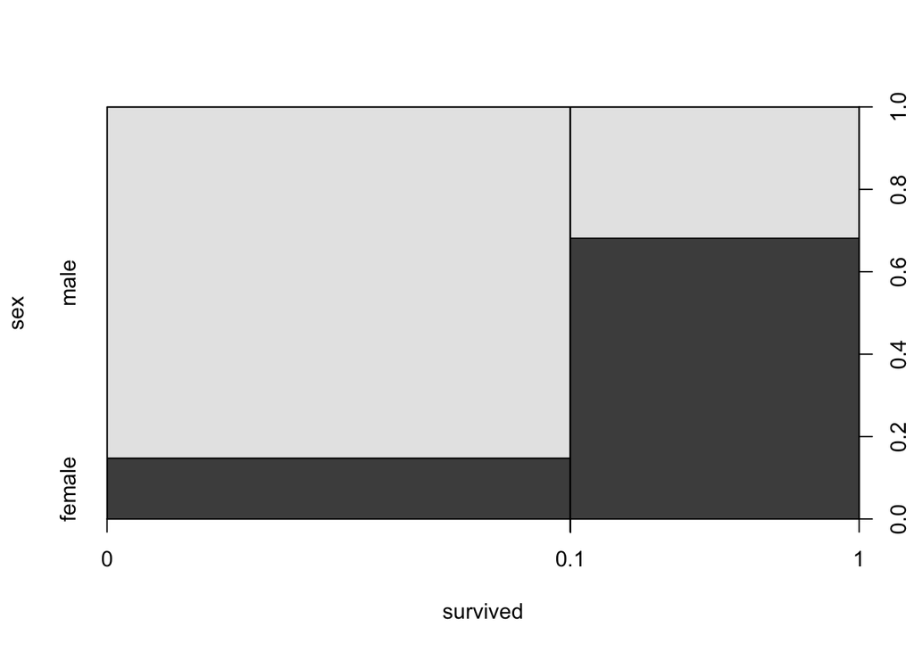

```r
plot(sex ~ survived, data=titanic)
```

## Questionnaire Data

The New York City dataset we looked at last class is a nice first example because it has already been scrubbed clean. Often, the data come to us in a relatively messy format. For example, the class questionnaire….

```r
x <- read.csv("stat_230_survey_raw.csv")
```

** A bit of a sidebar:** Typically, we like to use the `as.is=TRUE` argument when we run the `read.csv()` command. Here is a bit about why we might care. We’ll start by checking the type of each column in the data frame:

```r
str(x)
```

```
## 'data.frame':    93 obs. of  24 variables:
##  $ Pcredit        : num  0.8 1 1 0.5 1 1 1 0.8 0.75 1 ...
##  $ UorG           : Factor w/ 4 levels "","Graduate student",..: 2 2 4 4 2 4 2 4 2 4 ...
##  $ Year           : Factor w/ 6 levels "","1 = freshman or first year grad",..: 2 3 5 5 2 4 2 4 2 3 ...
##  $ Major          : Factor w/ 6 levels "","Humanities",..: 5 3 6 3 3 5 6 1 6 5 ...
##  $ Gender         : Factor w/ 3 levels "","Female","Male": 2 3 3 3 2 2 2 2 3 3 ...
##  $ Height         : Factor w/ 35 levels "","162","4' 2\"",..: 14 25 33 25 16 14 18 1 25 10 ...
##  $ Weight         : num  130 240 170 203 130 ...
##  $ Handedness     : Factor w/ 4 levels "","Ambidextrous",..: 4 4 4 4 4 4 4 4 4 4 ...
##  $ Politics       : Factor w/ 6 levels "","Moderate",..: 4 2 3 4 2 4 6 2 2 4 ...
##  $ Political_Party: Factor w/ 5 levels "","Democratic",..: 2 4 5 2 3 2 2 3 2 2 ...
##  $ SAT_CR         : Factor w/ 16 levels "","670","680",..: 5 9 15 15 1 7 8 1 14 5 ...
##  $ SAT_M          : Factor w/ 16 levels "","600","660",..: 15 4 13 15 1 7 11 1 2 15 ...
##  $ SAT_W          : Factor w/ 14 levels "","670","700",..: 8 3 13 12 1 5 5 1 9 13 ...
##  $ High.school.GPA: num  4 3.62 4.4 4 3.9 4 4.25 NA 3.95 4 ...
##  $ College.GPA    : num  3.8 3.7 3.95 3.92 3.9 NA 3.9 NA 3.86 3.88 ...
##  $ Television     : Factor w/ 24 levels "","0","0.01",..: 2 18 19 15 21 21 18 1 9 14 ...
##  $ Web            : num  120 30 90 360 100 120 90 NA 30 60 ...
##  $ Exercise       : num  10 10 20 40 30 0 30 NA 60 30 ...
##  $ Academics      : int  240 240 240 45 360 0 120 NA 480 360 ...
##  $ Attendance     : num  0.9 0.97 1 0.95 1 0.9 1 NA 0.95 0.75 ...
##  $ Computer       : Factor w/ 3 levels "","Mac","Windows": 3 2 2 3 3 2 2 1 2 2 ...
##  $ Pulse          : int  68 87 NA NA NA 60 72 NA 54 72 ...
##  $ Haircut        : Factor w/ 32 levels "","$10 ","$45 ",..: 22 11 14 23 6 19 24 1 10 14 ...
##  $ TimeMachine    : Factor w/ 60 levels "","0","0 CE",..: 55 36 33 1 4 42 37 1 11 51 ...
```

Suppose we want to explore the hypothesis of whether the average pulse for all females is different than that for males. I threw the word **all** in there to reflect that this is a question about the mean pulse in a population. We can try to answer this question using our sample, of course, with an assumption that our sample is a representative sample from the population.

Let’s take a peek at the variables in question first to see what our sample tells us.

```r
class(x$Gender)
```

```
## [1] "factor"
```

```r
table(x$Gender)
```

```
##
##        Female   Male
##      1     46     46
```

That stray 1 is actually a missing value for Gender, but is currently coded as a blank. Note that blanks appeared as one of the distinct values in the column in the .csv file, so R thought that this is an appropriate level of the factor.

```r
levels(x$Gender)
```

```
## [1] ""       "Female" "Male"
```

The way that R is meant to encode missing values is to use an `NA`. Because we exported this data file from Google Docs, we have to recode this ourselves.

```r
x$Gender[x$Gender == ""] <- NA
levels(x$Gender)
```

```
## [1] ""       "Female" "Male"
```

```r
table(x$Gender)
```

```
##
##        Female   Male
##      0     46     46
```

It’s still there… how annoying. Lesson learned: factors can be annoying to clean up in R. You can’t just discard a particular level or add one on the fly. So to get around this problem, we can simply add `as.is=` in the `read.csv()` command when we load in the data.

```r
x <- read.csv("stat_230_survey_raw.csv", as.is = TRUE)
x$Gender[x$Gender == ""] <- NA
table(x$Gender)
```

```
##
## Female   Male
##     46     46
```

```r
class(x$Gender)
```

```
## [1] "character"
```

So now, `Gender` is no longer a factor. `chr` stands for character, aka. text. That’s okay, R will know to convert `Gender` to factor type when needed.

Let’s examine the `Pulse` variable.

```r
summary(x$Pulse)
```

```
##    Min. 1st Qu.  Median    Mean 3rd Qu.    Max.    NA's
##   20.00   60.00   70.00   68.33   74.00  100.00      26
```

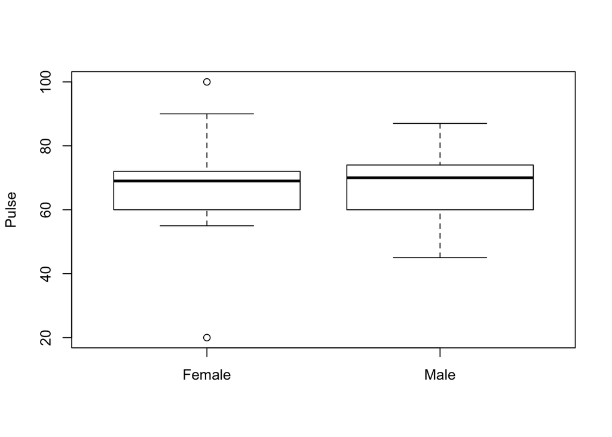

```r
boxplot(Pulse ~ Gender, data=x, ylab="Pulse")
```

Does it appear that the mean pulse for females might differ from the mean pulse for males? Formally, we are asking about these two hypotheses:

$$H_0: \mu_{F} = \mu_M \;\;\;\;\;\text{ vs. }\;\;\;\;\;H_a: \mu_F \ne \mu_M$$
where $\mu_F$ and $\mu_M$ are the mean pulses in the population of females and males, respectively.

There are several ways we can answer this question.

### 2-Sample T-test

```r
t.test(Pulse ~ Gender, data=x)
```

```
##
##  Welch Two Sample t-test
##
## data:  Pulse by Gender
## t = -0.24258, df = 60.896, p-value = 0.8091
## alternative hypothesis: true difference in means is not equal to 0
## 95 percent confidence interval:
##  -6.162229  4.828895
## sample estimates:
## mean in group Female   mean in group Male
##             68.00000             68.66667
```

How do we interpret the results here? We have a p-value of 0.8091. At any reasonable significance level $\alpha$ (say, 0.05), we do not have evidence to suggest that the mean pulse differs between the genders. We also get a 95% confidence interval of (-6.16, 4.83). We might say that we are 95% confident that the difference $\mu_F-\mu_M$ is between (-6.16, 4.83). How did we know it was $\mu_F-\mu_M$ and not $\mu_M-\mu_F$? Because in the line below ‘sample estimates’, we see ‘Female’ before ‘Male’.

Some questions you may have:

- The p-value here corresponds to a 2-sided alternative hypothesis. What can I do if I wanted a 1-sided alternative hypothesis test instead?

Questions like these can generally be answered by pulling up the help page, i.e. `?t.test`. You will see that you can add the argument `alternative=` to be ‘less’ or ‘greater’, but that it defaults to ‘two.sided’.

- What if I want a confidence interval for a different confidence level?

The help file suggests that `conf.level=` is the argument to be modified.